# Markdown example

Stacey Borrego

1/14/2022

This always shows up and I always leave it. It specifies any global settings to be applied to the R Markdown script. The example sets all code chunks as “echo=TRUE”, meaning they will be included in the final rendered version.

```r
knitr::opts_chunk$set(echo = TRUE)
```

# My first markdown

## I’m so excited

Let’s do some *really* **fun** stuff today!

### First

Start with a description for the purpose of this document. Your future self with sthank you.

The text that we write here shows up in our document.  
You can look the [Rmarkdown Cheatsheet](https://www.rstudio.com/wp-content/uploads/2015/02/rmarkdown-cheatsheet.pdf) to find more formatting options.

**Spacing Matters!**

If your list or something else does not render correctly, make you are using the correct spacing.

A list that won’t work: * because * I didn’t leave a space

A list that will render properly:

- because
- I left a space

**New Lines**

Formatting in your markdown file doesn’t matter especially when it comes to new lines. You have to format a line return with two spaces after the last line to get the next line to actually return on the next line. So keep your code clean looking and use the formatting characters to render your markdown file properly!

*Example of NO double space on line return* xxxxxxxxxxxxxxxxxxxxxxxxxxxxxxxxxxxxxxxxxxxxxxxxxxxxxxxxxxxxxxxxxxxxxxxxxxxxxxxx ………………..

*Example of double space on line return*  
xxxxxxxxxxxxxxxxxxxxxxxxxxxxxxxxxxxxxxxxxxxxxxxxxxxxxxxxxxxxxxxxxxxxxxxxxxxxxxxx  
………………..

**HTML Components**

- Leave a large space you can use `<br>` to create breaks
- Insert image from website with `<img src="web_address">`
- Insert links `<a href=""> </a>`

4 line breaks above me!

Links with HTML

[Helpful Link](https://beatrizmilz.github.io/RStudio_Certification/slides.html#10)

Links with markdown

[Helpful Link](https://beatrizmilz.github.io/RStudio_Certification/slides.html#10)

### Second

Let’s use our R skills!

Make a code chunk. You can use R, bash, or python in the code chunks. We will stick to R today.

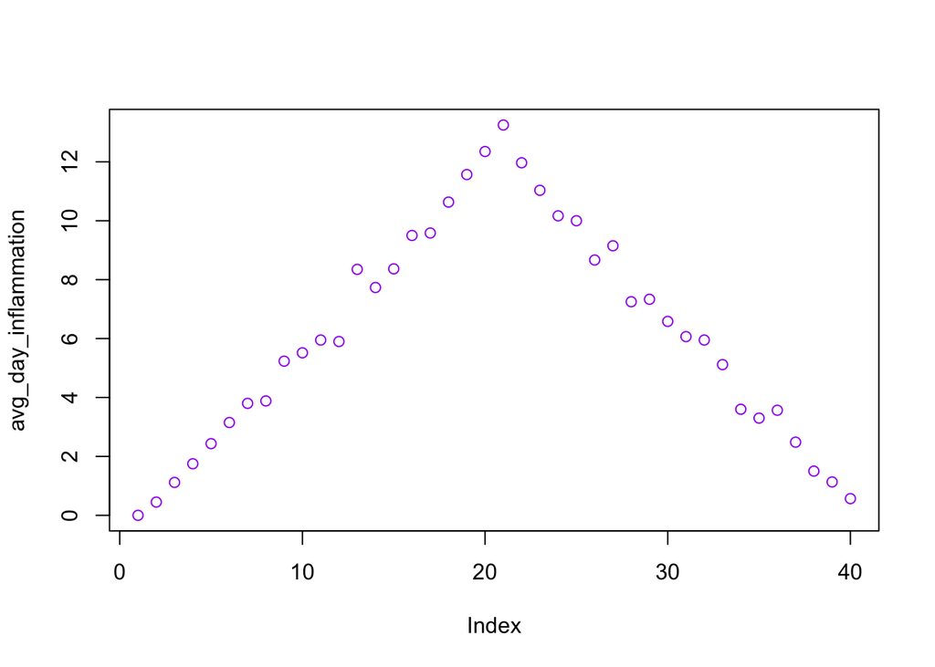

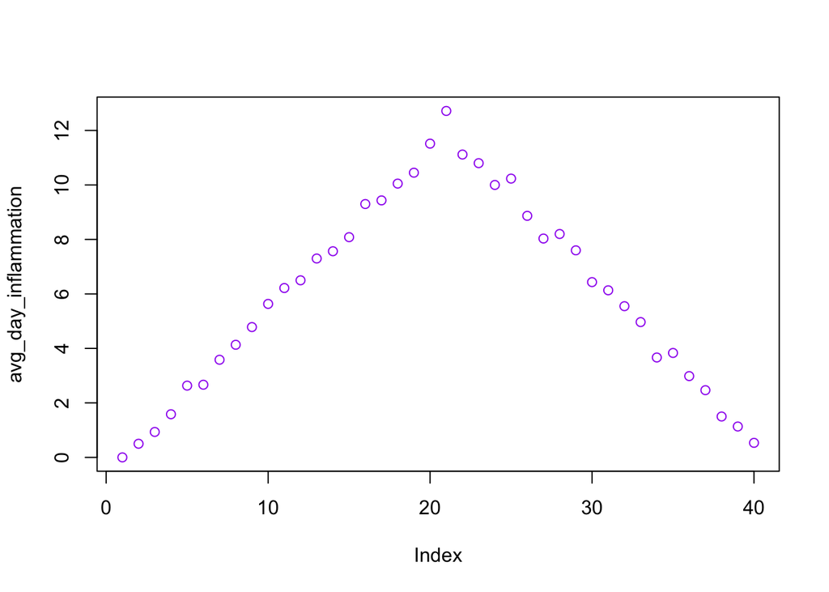

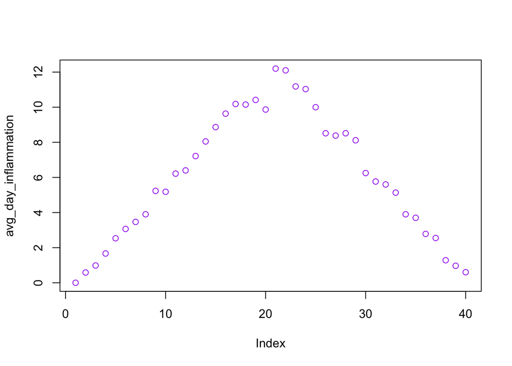

```r
analyze <- function(filename) {
  # Plots the average, min, and max inflammation over time.
  # Input is character string of a csv file.
  dat <- read.csv(file = filename, header = FALSE)
  avg_day_inflammation <- apply(dat, 2, mean)
  plot(avg_day_inflammation,
       col = "purple")
}

filenames <- list.files(path = "/Users/stacey/Desktop/data",
                        pattern = "inflammation-[0-9]{2}.csv",
                        full.names = TRUE)

for (file in filenames[1:3]){
  analyze(file)
}
```

Code is not rendered but results are by using `echo=FALSE`

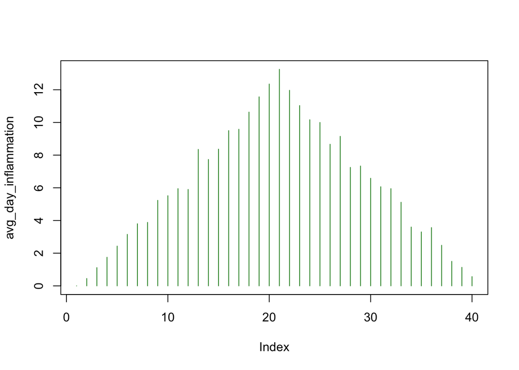

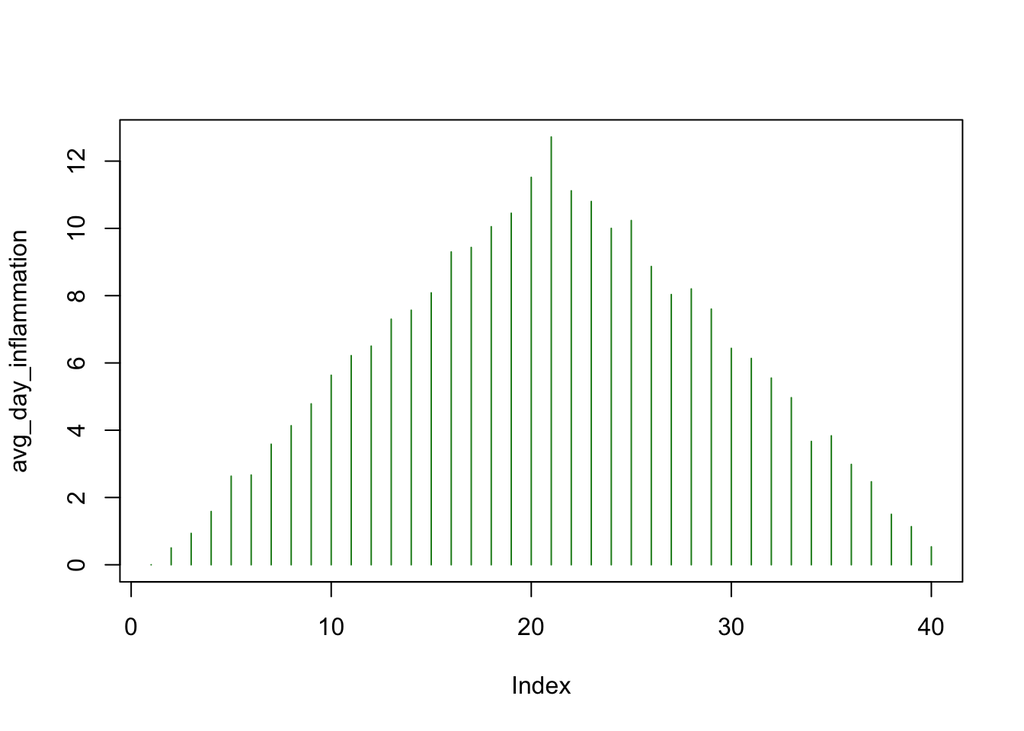

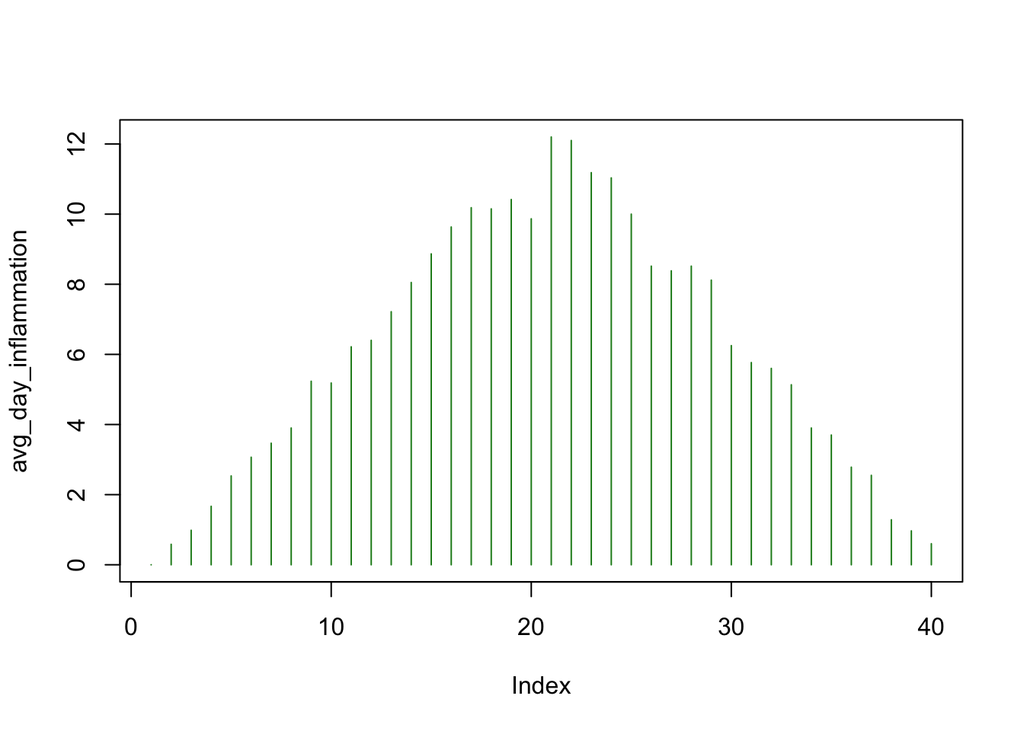